# Events with the most impact on Public Health and Economy in the USA 1950 - 2011 (Based on data from NOAA)

Santhosh Shankar

October 25, 2015

# Synopsis

Storms and other severe weather events can cause both public health and economic problems for communities and municipalities. Many severe events can result in fatalities, injuries, and property damage, and preventing such outcomes to the extent possible is a key concern.

This report analyses [NOAA storm database](https://d396qusza40orc.cloudfront.net/repdata%2Fdata%2FStormData.csv.bz2) and address the following questions:

**1. Across the United States, which types of events are most harmful with respect to population health?**

This analysis shows that more than 95,000 people have been injured (90K) or killed (> 5K) by the most harmful events such as TORNADOES. The second highest toll is due to EXCESSIVE HEAT (> 8k). The top 10 calamity event types on public health have been listed in this report.

**2. Across the United States, which types of events have the greatest economic consequences?**

This analysis also shows the events with the most economic consequences are the FLOODS with over 150 billions of USD in damages (property and Corp) followed by the HURRICANES, TYPHOONS with nearly 72 billions of USD and TORNADOES not lagging too much behind in damages. The top 10 calamity event types on economy have been listed in this report.

# Data Processing

#### Load the required libraries

```r
require(plyr)
require(knitr)
```

```r
require(ggplot2)
require(grid)
```

#### Download the [NOAA storm database](https://d396qusza40orc.cloudfront.net/repdata%2Fdata%2FStormData.csv.bz2) file (.csv format) and read the data.

```r
fileUrl <- "https://d396qusza40orc.cloudfront.net/repdata%2Fdata%2FStormData.csv.bz2"

#filename <- "repdata-data-StormData.csv.bz2"
filename <- "repdata-data-StormData.csv"

# Download the file
if (!file.exists(filename)) {
    download.file(fileUrl, destfile = filename, method = "auto")
    #bunzip2("repdata-data-StormData.csv.bz2", destname = filename)
}

stdata <- read.csv(filename, stringsAsFactors = FALSE,
                 strip.white = TRUE, header = TRUE)
```

#### Cleaning data and processing data format as required for our analysis.

**Following processing/formating has been done for this purpose**

```r
stdata <- stdata[ , c("EVTYPE", "BGN_DATE", "FATALITIES", "INJURIES", "PROPDMG", "PROPDMGEXP", "CROPDMG", "CROPDMGEXP")]

# Format the date
stdata$BGN_DATE <- as.POSIXct(stdata$BGN_DATE,format="%m/%d/%Y %H:%M:%S")

PRPDMG_multiplier <- mapvalues(stdata$PROPDMGEXP,
                        c("K", "M", "", "B", "m", "+", "0", "5", "6", "?", "4",
                            "2", "3", "h", "7", "H", "-", "1", "8"),
                        c(1e3, 1e6, 1, 1e9, 1e6,  1,  1, 1e5, 1e6,  1, 1e4,
                          1e2, 1e3, 1, 1e7, 1e2,  1, 10, 1e8))

CRPDMG_multiplier <- mapvalues(stdata$CROPDMGEXP,
                        c("", "M", "K", "m", "B", "?", "0", "k", "2"),
                        c( 1, 1e6, 1e3, 1e6, 1e9, 1, 1, 1e3, 1e2))

stdata$PROPDMGDOLLAR <- as.numeric(PRPDMG_multiplier) * stdata$PROPDMG
stdata$CROPDMGDOLLAR <- as.numeric(CRPDMG_multiplier) * stdata$CROPDMG

remove(PRPDMG_multiplier)
remove(CRPDMG_multiplier)

# Add new column for Total Damage - sum of property and Corp
stdata$TOTALDMGDOLLAR <- stdata$PROPDMGDOLLAR + stdata$CROPDMGDOLLAR

# Making the summary 9based on Event type) of the data using ddply
stdata <- ddply(stdata, .(EVTYPE), summarize,
                    propdamage = sum(TOTALDMGDOLLAR),
                    injuries= sum(INJURIES),
                    fatalities = sum(FATALITIES),
                    persdamage = sum(INJURIES) + sum(FATALITIES))
```

# Results

#### 1. Across the United States, which types of events (as indicated in the EVTYPE variable) are most harmful with respect to population health?

By looking at the graphs below, The TORNADOES are the most harmful event to population/public health with more than 95,000 people either injured (>90k) or fatalities (>5K).

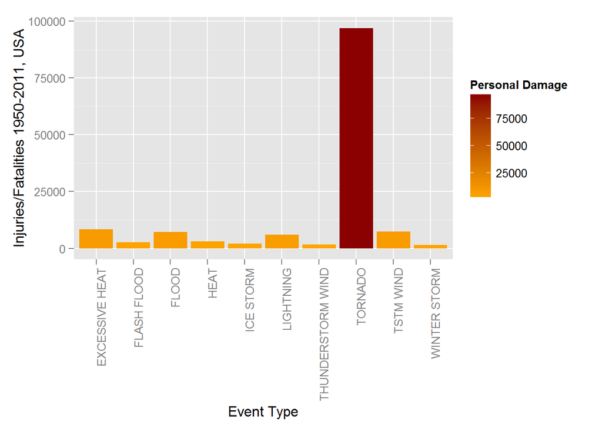

```r
stdata <- stdata[order(stdata$persdamage, decreasing = TRUE),]

# Plot the graph for total damage (injuries + fatalities)
ph_plot <- qplot(x = EVTYPE, y = persdamage, fill = persdamage,
                data = head(stdata, 10), geom = "bar", stat = "identity",
                            position="dodge") +
                labs(x = "Event Type",
                     y = "Injuries/Fatalities 1950-2011, USA") +
                scale_fill_gradient("Personal Damage", low = "orange",
                                    high = "darkred") +
                theme(axis.text.x = element_text(angle=90, hjust=1))

print(ph_plot)
```

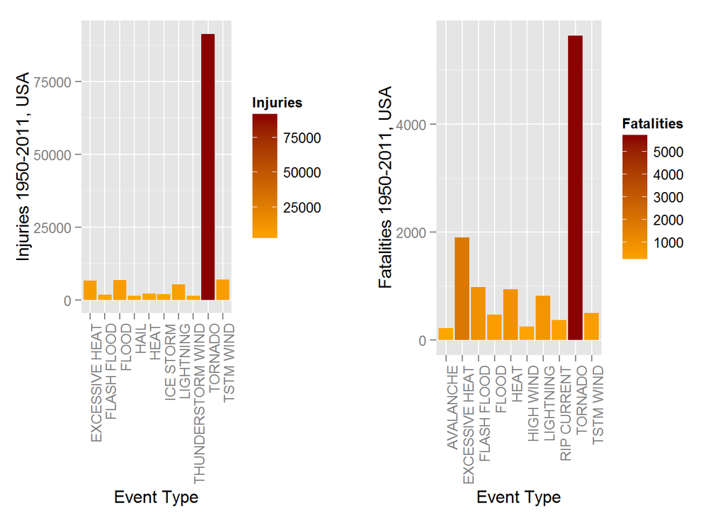

```r
stdata <- stdata[order(stdata$injuries, decreasing = TRUE),]

# Plot the injury graph
inj_plot <- qplot(x = EVTYPE, y = injuries, fill = injuries,
                data = head(stdata, 10), geom = "bar", stat = "identity",
                            position="dodge") +
                labs(x = "Event Type", y = "Injuries 1950-2011, USA") +
                scale_fill_gradient("Injuries", low = "orange",
                                    high = "darkred") +
                theme(axis.text.x = element_text(angle=90, hjust=1))

stdata <- stdata[order(stdata$fatalities, decreasing = TRUE),]

fatl_plot <- qplot(x = EVTYPE, y = fatalities, fill = fatalities,
                data = head(stdata,10), geom = "bar", stat = "identity",
                            position="dodge") +
                labs(x = "Event Type", y = "Fatalities 1950-2011, USA") +
                scale_fill_gradient("Fatalities", low = "orange",
                                    high = "darkred") +
                theme(axis.text.x = element_text(angle=90, hjust=1))

# Plot both for injuries and fatalities
grid.newpage()
pushViewport(viewport(layout = grid.layout(1, 2)))
print(inj_plot, vp = viewport(layout.pos.row = 1,
                                  layout.pos.col = 1))
print(fatl_plot, vp = viewport(layout.pos.row = 1,
                                  layout.pos.col = 2))
```

#### 2. Across the United States, which types of events have the greatest economic consequences?

This analysis also shows the events with the most economic consequences are the FLOODS with over 150 billions of USD in damages (property and Corp) followed by the HURRICANES, TYPHOONS with nearly 72 billions of USD and TORNADOES not lagging too much behind in damages.

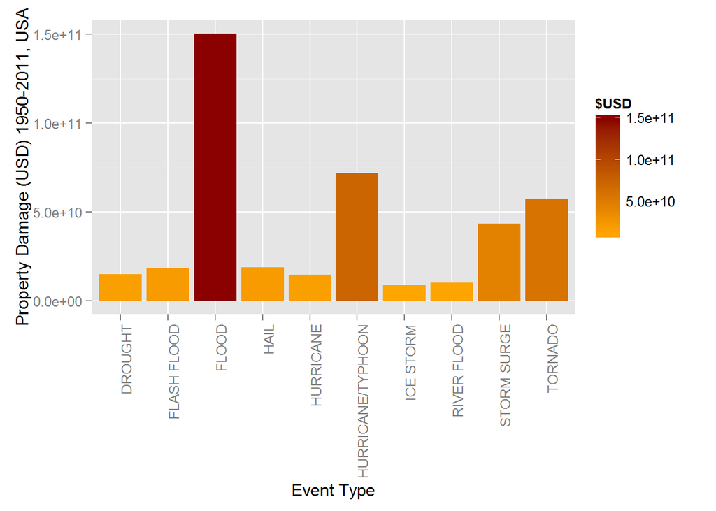

```r
# Order the data
stdata <- stdata[order(stdata$propdamage, decreasing = TRUE),]

# Plot the property Damage graph
prop_plot <- qplot(x = EVTYPE, y = propdamage, fill = propdamage,
                    data = head(stdata, 10), geom = "bar", stat = "identity",
                                position="dodge") +
                    labs(x = "Event Type",
                         y = "Property Damage (USD) 1950-2011, USA") +
                    scale_fill_gradient("$USD", low = "orange",
                                        high = "darkred") +
                    theme(axis.text.x = element_text(angle=90, hjust=1))

print(prop_plot)
```